# Untitled

2025-04-20

# **Pregunta 1**

### Un laboratorio de control de calidad alimentario quiere evaluar si los niveles de ciertos nutrientes en una muestra de productos cumplen con los estándares esperados. Se tienen mediciones de cuatro componentes clave en 60 muestras de productos. Se evaluará si el vector de medias observado es consistente con los valores estándar definidos por la regulación.

```
##    Proteína Carbohidratos   Grasas     Fibra
## 1  86.74311      78.24781 11.32743  6.681944
## 2  88.26420      78.35255 10.02141  6.277156
## 3  93.79781      72.25451 14.58581  9.444605
## 4  94.47417      72.21773 14.85202  9.345791
## 5  92.15488      74.88395 14.89951  8.486528
## 6  92.21211      76.16600 12.48782  8.160316
## 7  86.23836      76.33716 12.40981  5.246241
## 8  89.57979      74.37011 13.18113  6.417884
## 9  89.68540      77.03145 11.85257  5.249487
## 10 90.00854      76.20616 12.11757  7.328829
## 11 87.58390      74.22256 12.81966  7.731056
## 12 91.01577      74.77647 14.74967  7.117002
## 13 92.93621      76.79268 12.14382  7.113345
## 14 95.23114      71.62869 15.50351  8.270104
```

[output cut: 46 more lines]

## Parámetros para la prueba

```
## El tamaño de muestra 'n' es: 60
```

```
## El número de variables 'p' es: 4
```

```
## La matriz de varianza-covarianza es:
```

```
##      [,1] [,2] [,3] [,4]
## [1,] 10.0 -4.5  3.5  3.5
## [2,] -4.5  4.0 -2.5 -2.5
## [3,]  3.5 -2.5  2.0  1.5
## [4,]  3.5 -2.5  1.5  2.0
```

## **Resumen Gráfico y Numérico por Variable**

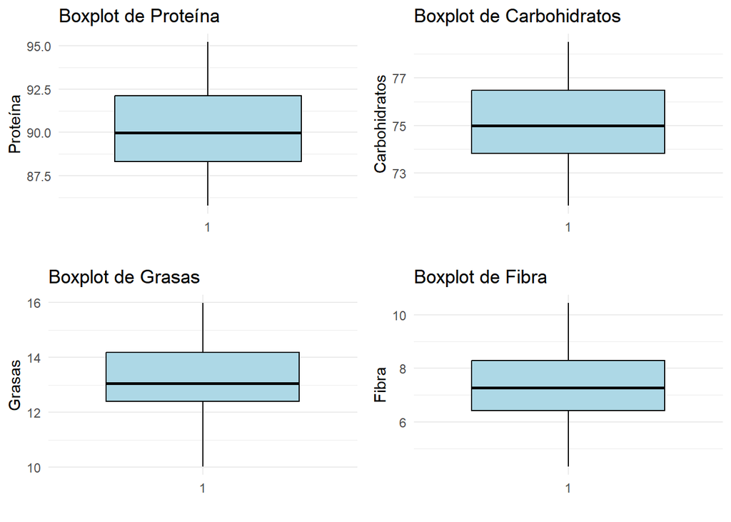

```
##     Proteína     Carbohidratos       Grasas          Fibra
##  Min.   :85.76   Min.   :71.63   Min.   :10.02   Min.   : 4.321
##  1st Qu.:88.33   1st Qu.:73.82   1st Qu.:12.40   1st Qu.: 6.428
##  Median :89.99   Median :75.00   Median :13.06   Median : 7.278
##  Mean   :90.16   Mean   :75.02   Mean   :13.24   Mean   : 7.353
##  3rd Qu.:92.12   3rd Qu.:76.47   3rd Qu.:14.18   3rd Qu.: 8.285
##  Max.   :95.23   Max.   :78.51   Max.   :15.99   Max.   :10.445
```

## **Diagrama de dispersión**

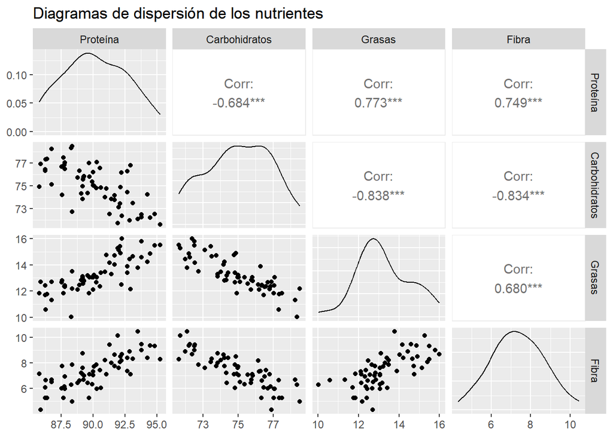

### La correlación entre proteína y grasas es alta y positiva (r = 0.773), lo cual indica que a mayor contenido de proteína, también aumenta el contenido de grasas.

### Existe una correlación negativa entre proteína y carbohidratos (r = -0.684), lo que sugiere que los alimentos con mayor proteína tienden a tener menos carbohidratos.

### La correlación entre carbohidratos y grasas es fuerte y negativa (r = -0.838), indicando una relación inversa entre estos dos nutrientes.

### La fibra se relaciona positivamente con la proteína (r = 0.749) y las grasas (r = 0.680), mientras que tiene una correlación negativa significativa con los carbohidratos (r = -0.834).

## **Identificacion de valores atipicos multivariados**

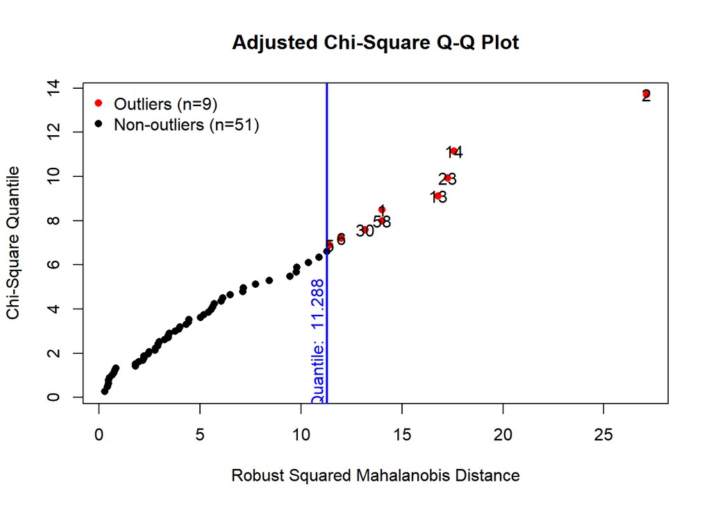

### Aunque se detectaron 9 outliers en los 60 datos, no se eliminaron porque podrían representar variabilidad real y útil del fenómeno estudiado. Quitarlos podría distorsionar los resultados y reducir la representatividad del análisis.

## **Supuesto de normalidad**

### H0: Los datos siguen una distribucion normal multivariada

### H1: Los datos no siguen una distribucion normal multivariada

### alpha = 0.05

```
##
##  Shapiro-Wilk normality test
##
## data:  Z
## W = 0.97358, p-value = 0.2177
```

### Dado que el valor-p es mayor a 0.05, no se rechaza la hipótesis nula de normalidad. Por lo tanto, los datos presentan evidencia suficiente para suponer que siguen una distribución normal multivariada.

## **Prueba de hipótesis para el vector de medias**

### H0: El vector de medias muestrales es igual al vector de medias hipotéticas

### H1: El vector de medias muestrales no es igual al vector de medias hipotéticas

### alpha = 0.05

```
## Estadística Z^2: 10.83516
```

```
## p-valor: 0.02848043
```

### Con un nivel de significancia de 0.05, el p-valor obtenido es 0.0285, que es menor que el nivel de significancia. Por lo tanto, rechazamos la hipótesis nula y concluimos que hay evidencia estadística suficiente para afirmar que el vector de medias muestrales es significativamente diferente al vector de medias hipotéticas.

## **Prueba de Bartlett para la Matriz de Covarianza**

### H0: la matriz de covarianza es igual a la Matriz dada

### H1: la matriz de covarianza de la muestra es diferente de la matriz de covarianza dada

```
##        Bartlett's Test for One Sample Covariance Matrix
##
## Chi-Squared Value = 15.32445 , df = 10  and p-value: 0.121
```

### Con un nivel de significancia de 0.05, el p-valor obtenido es 0.121, que es mayor que el nivel de significancia. Por lo tanto, no rechazamos la hipótesis nula y concluimos que no hay evidencia suficiente para afirmar que la matriz de covarianza de la muestra es diferente de la matriz de covarianza dada.

## **Pregunta 2**

### Para este analisis se usan datos correspondientes a diversas características de muestras de café, tales como la acidez, cafeína, aroma y cuerpo. Cada una de estas variables representa un atributo sensorial importante para la calidad del café, y el objetivo del análisis es verificar si el vector de medias de estas variables es igual a un vector de medias hipotético previamente conocido. Con este fin, se aplican métodos estadísticos multivariados, como la prueba de Hotelling T2, para evaluar la igualdad de las medias y realizar un análisis más detallado sobre la variabilidad y las relaciones entre las variables.

```
## # A tibble: 50 × 4
##    acidez cafeína aroma cuerpo
##     <dbl>   <dbl> <dbl>  <dbl>
##  1   4.72   0.874  8.04   5.57
##  2   4.85   1.14   8.31   5.32
##  3   4.65   1.27   7.31   6.56
##  4   3.91   1.19   7.41   5.76
##  5   4.53   1.49   7.04   6.69
##  6   4.31   1.10   9.08   6.82
##  7   4.53   1.15   6.75   6.23
##  8   4.64   0.982  6.67   5.41
##  9   4.42   1.38   8.67   5.73
## 10   4.02   1.10   7.41   5.40
## # ℹ 40 more rows
```

## **Analisis exploratorio de los datos**

### **Visualización y Resumen Descriptivo de los Datos**

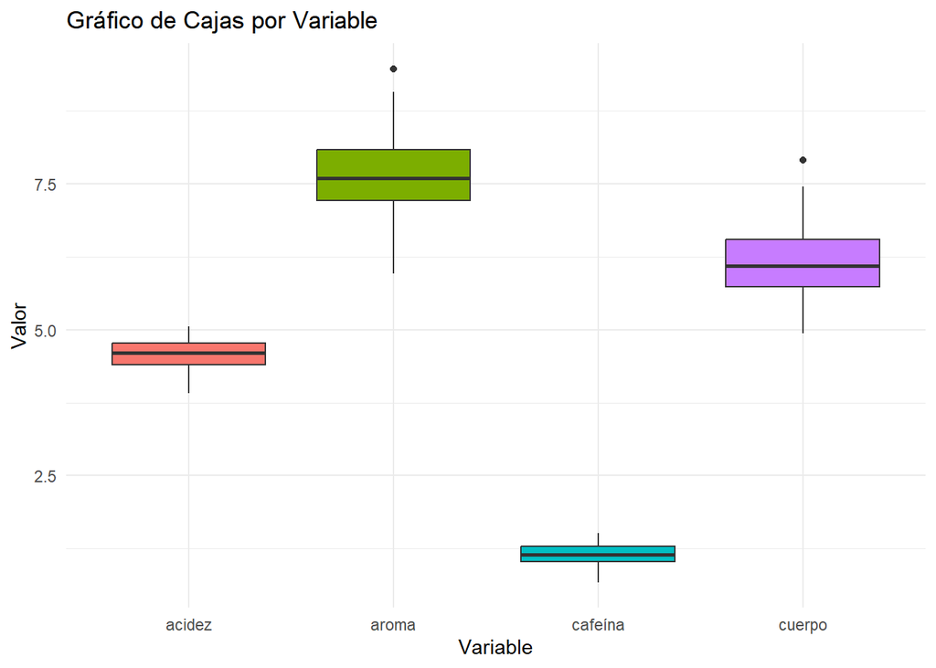

```
## Descriptive Statistics
## datos2
## N: 50
##
##                     acidez    aroma   cafeína   cuerpo
## ----------------- -------- -------- --------- --------
##              Mean     4.59     7.64      1.15     6.13
##           Std.Dev     0.25     0.71      0.21     0.67
##               Min     3.91     5.96      0.68     4.94
##                Q1     4.40     7.21      1.03     5.73
##            Median     4.60     7.60      1.15     6.10
##                Q3     4.77     8.09      1.29     6.55
##               Max     5.06     9.47      1.51     7.90
##               MAD     0.26     0.71      0.20     0.67
##               IQR     0.37     0.87      0.26     0.82
##                CV     0.06     0.09      0.18     0.11
##          Skewness    -0.32     0.06     -0.21     0.44
##       SE.Skewness     0.34     0.34      0.34     0.34
##          Kurtosis    -0.22    -0.03     -0.44    -0.26
##           N.Valid    50.00    50.00     50.00    50.00
##                 N    50.00    50.00     50.00    50.00
##         Pct.Valid   100.00   100.00    100.00   100.00
```

### Acidez: Presenta una distribución simétrica y estable, con baja variabilidad (CV = 0.06) y sin valores atípicos detectados en el gráfico de caja.

### Cafeína: La distribución es simétrica y la variabilidad es moderada (CV = 0.18), sin valores extremos relevantes.

### Aroma: Aunque la distribución es en su mayoría estable, el gráfico de caja muestra algunos valores atípicos, lo que sugiere mayor variabilidad en esta variable.

### Cuerpo: Similar a aroma, el gráfico de caja indica valores atípicos, aunque la distribución sigue siendo mayormente simétrica con una variabilidad moderada (CV = 0.11).

## **Grafico de correlacion**

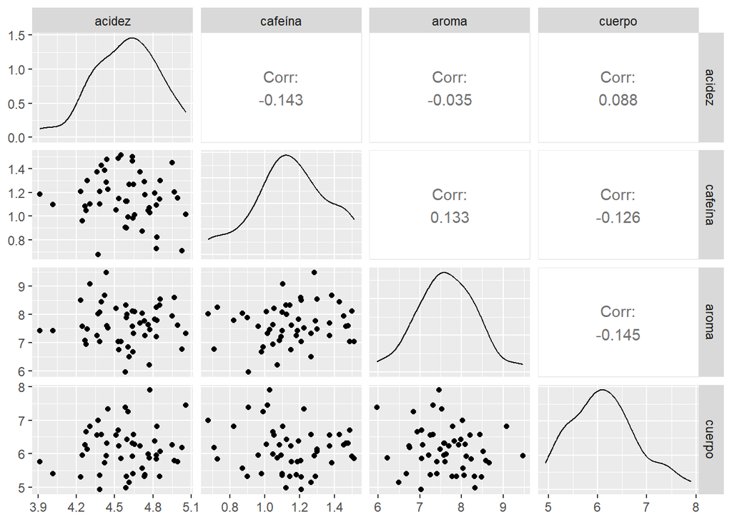

### Acidez y cafeína: La correlación entre estas variables es débilmente negativa (-0.14), lo que indica que, en general, a medida que aumenta la acidez, la cafeína tiende a disminuir levemente, aunque la relación es casi nula.

### Acidez y cuerpo: La correlación entre acidez y cuerpo es positiva, pero muy débil (0.09), lo que sugiere que no existe una relación clara entre estas dos variables.

### Cafeína y aroma: Existe una ligera correlación positiva (0.13) entre cafeína y aroma, lo que indica que un aumento en la cafeína está ligeramente asociado con un aumento en el aroma.

### Cafeína y cuerpo: La correlación entre cafeína y cuerpo es débilmente negativa (-0.13), lo que sugiere que no hay una relación fuerte, pero hay una ligera tendencia a que, al aumentar la cafeína, el cuerpo disminuya.

### Aroma y cuerpo: La correlación entre aroma y cuerpo es débilmente negativa (-0.14), indicando que, en general, no hay una relación fuerte entre estas dos variables.

## **Identificando Valores Atípicos**

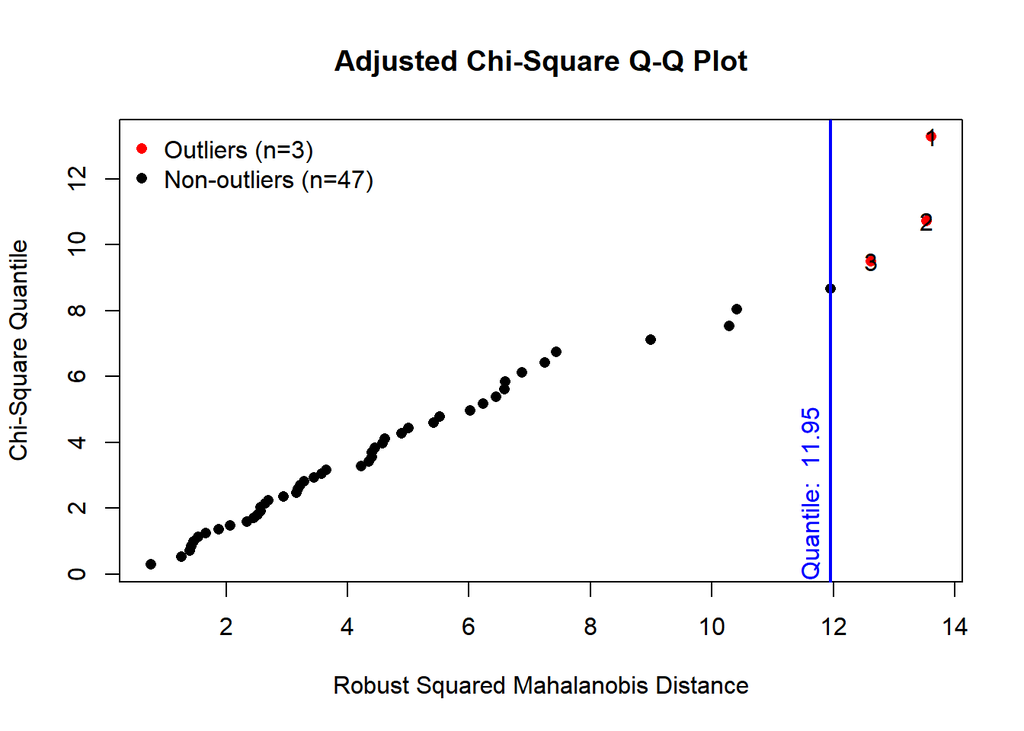

### Los individuos identificados como atípicos no corresponden a errores de medición ni a valores imposibles; representan observaciones válidas dentro del contexto del estudio. Por lo tanto, se decidió conservarlos.

## **Supuesto de normalidad**

### H0: Los datos siguen una distribucion normal multivariada

### H1: Los datos no siguen una distribucion normal multivariada

### alpha = 0.05

```
##              Test         Statistic            p value Result
## 1 Mardia Skewness  8.89790127475483  0.984059906451315    YES
## 2 Mardia Kurtosis -1.69360137305678 0.0903410569734695    YES
## 3             MVN              <NA>               <NA>    YES
```

### Con un nivel de significancia del 5%, los resultados de la prueba de normalidad multivariada (MVN) no muestran evidencia suficiente para rechazar la hipótesis nula de normalidad. Esto indica que las variables siguen una distribución normal multivariada

## Prueba de Hotelling T²

### H0: μ = μ₀ = (4.7, 1.2, 6.8, 6.0)

### H1: μ ≠ μ₀

### alpha = 0.05

```
##        One Sample Hotelling T Square Test
##
## Hotelling T Sqaure Statistic = 96.0499
##  F value = 22.542 , df1 = 4 , df2 = 46 , p-value: 2.34e-10
##
##                    Descriptive Statistics
##
##           acidez    cafeína      aroma     cuerpo
## N     50.0000000 50.0000000 50.0000000 50.0000000
## Means  4.5858101  1.1515354  7.6400996  6.1279081
## Sd     0.2525605  0.2080062  0.7062378  0.6745079
##
##
##                  Detection important variable(s)
##
##            Lower    Upper Mu0 Important Variables?
## acidez  4.467523 4.704097 4.7                FALSE
## cafeína 1.054116 1.248955 1.2                FALSE
## aroma   7.309333 7.970867 6.8               *TRUE*
## cuerpo  5.812002 6.443814 6.0                FALSE
```

### La prueba de Hotelling T² indica que todas las variables (acidez, cafeína y cuerpo) son iguales a sus valores hipotéticos (mu0), ya que no muestran diferencias significativas. Sin embargo, el aroma presenta una diferencia significativa respecto a su valor hipotético.

# **Pregunta 5**

```
## # A tibble: 45 × 5
##    Cultivo  Peso Diametro Materia_Seca Rendimiento_ha
##    <chr>   <dbl>    <dbl>        <dbl>          <dbl>
##  1 Surcos   114.     5.44         21.5           27.3
##  2 Surcos   118.     5.80         20.8           22.1
##  3 Surcos   136.     5.77         20.4           26.5
##  4 Surcos   121.     6.39         19.1           28.8
##  5 Surcos   121.     5.96         22.0           22.1
##  6 Surcos   137.     6.13         19.1           26.4
##  7 Surcos   125.     5.99         23.3           24.5
##  8 Surcos   107.     5.98         22.3           21.9
##  9 Surcos   113.     6.68         19.6           22.0
## 10 Surcos   116.     5.89         18.5           21.8
## # ℹ 35 more rows
```

## **Estadística descriptiva**

### Resumen estadístico univariado de las variables respuesta por tipo de cultivo

### **Distribución y resumen del peso del tubérculo por tipo de cultivo**

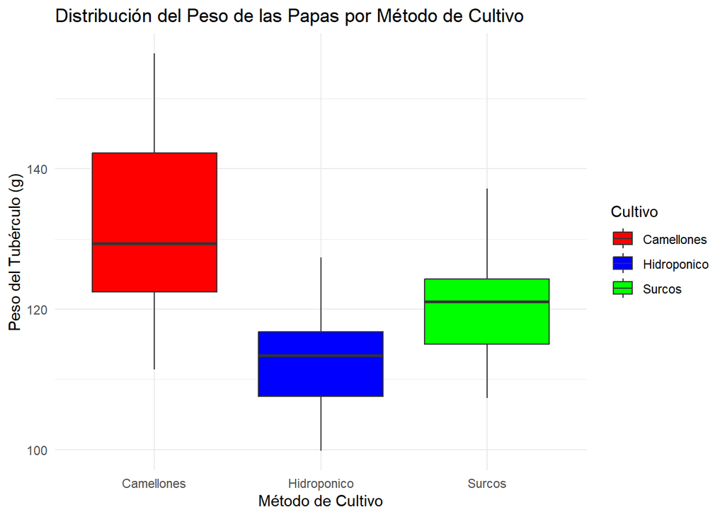

```
## Descriptive Statistics
## Peso by Cultivo
## Data Frame: datos5
## N: 45
##
##                     Camellones   Hidroponico   Surcos
## ----------------- ------------ ------------- --------
##              Mean       132.04        112.36   121.52
##           Std.Dev        13.11          6.94     8.45
##               Min       111.40         99.88   107.35
##                Q1       122.19        107.55   114.44
##            Median       129.33        113.41   121.11
##                Q3       143.42        117.03   124.61
##               Max       156.44        127.35   137.15
##               MAD        11.84          7.52     8.25
##               IQR        19.76          9.20     9.32
##                CV         0.10          0.06     0.07
##          Skewness         0.22          0.24     0.38
##       SE.Skewness         0.58          0.58     0.58
##          Kurtosis        -1.16         -0.54    -0.86
##           N.Valid        15.00         15.00    15.00
##                 N        15.00         15.00    15.00
##         Pct.Valid       100.00        100.00   100.00
```

### El análisis univariado muestra diferencias claras entre los tres métodos. El método por camellones presentó el mayor rendimiento promedio (132.04 g), aunque con la mayor variabilidad en los datos. En contraste, el método hidropónico tuvo el menor rendimiento (112.36 g), pero fue el más estable. El tercer método mostró valores intermedios tanto en rendimiento como en dispersión, lo que sugiere un equilibrio entre productividad y consistencia.

### **Distribución y resumen del diámetro del tubérculo por tipo de cultivo**

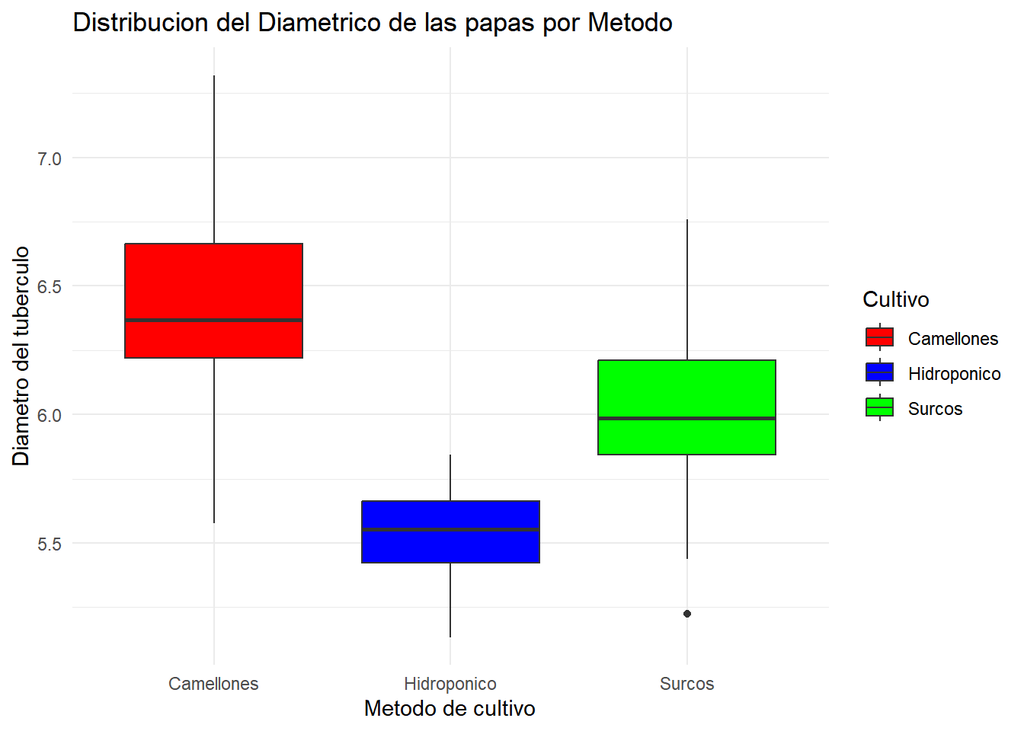

```
## Descriptive Statistics
## Diametro by Cultivo
## Data Frame: datos5
## N: 45
##
##                     Camellones   Hidroponico   Surcos
## ----------------- ------------ ------------- --------
##              Mean         6.45          5.55     6.03
##           Std.Dev         0.42          0.19     0.41
##               Min         5.58          5.13     5.23
##                Q1         6.22          5.41     5.80
##            Median         6.37          5.55     5.99
##                Q3         6.68          5.69     6.29
##               Max         7.32          5.84     6.76
##               MAD         0.41          0.21     0.28
##               IQR         0.45          0.24     0.37
##                CV         0.06          0.03     0.07
##          Skewness         0.06         -0.20    -0.03
##       SE.Skewness         0.58          0.58     0.58
##          Kurtosis        -0.23         -0.63    -0.49
##           N.Valid        15.00         15.00    15.00
##                 N        15.00         15.00    15.00
##         Pct.Valid       100.00        100.00   100.00
```

### En cuanto al diámetro, el método por camellones presentó el mayor valor promedio (6.45 cm), seguido del método por surcos (6.03 cm) y finalmente el método hidropónico (5.55 cm). Aunque el rendimiento en diámetro fue mayor en camellones, este método mostró una variabilidad ligeramente superior (desviación estándar = 0.42 cm). El método hidropónico fue nuevamente el más estable (CV = 0.03), pero con el diámetro promedio más bajo. El método por surcos presentó valores intermedios tanto en rendimiento como en dispersión.

### **Distribución y resumen del % de Materia seca del tubérculo por tipo de cultivo**

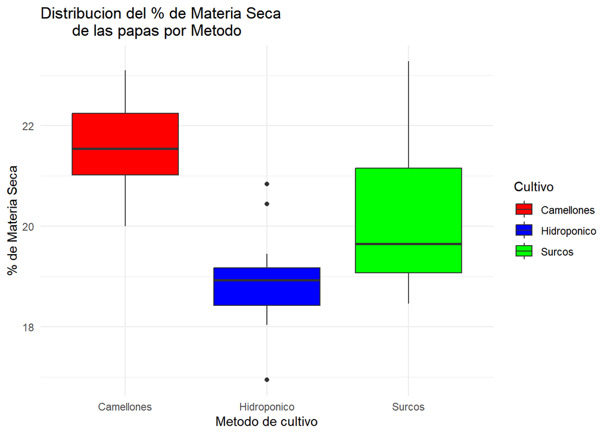

```
## Descriptive Statistics
## Materia_Seca by Cultivo
## Data Frame: datos5
## N: 45
##
##                     Camellones   Hidroponico   Surcos
## ----------------- ------------ ------------- --------
##              Mean        21.58         18.89    20.24
##           Std.Dev         0.93          0.95     1.47
##               Min        20.00         16.95    18.46
##                Q1        20.98         18.35    19.06
##            Median        21.54         18.93    19.65
##                Q3        22.36         19.24    21.49
##               Max        23.10         20.84    23.28
##               MAD         0.86          0.62     1.10
##               IQR         1.22          0.75     2.08
##                CV         0.04          0.05     0.07
##          Skewness        -0.14          0.21     0.60
##       SE.Skewness         0.58          0.58     0.58
##          Kurtosis        -1.15         -0.02    -0.98
##           N.Valid        15.00         15.00    15.00
##                 N        15.00         15.00    15.00
##         Pct.Valid       100.00        100.00   100.00
```

### **Distribución y resumen del Rendimiento por hectarea del tubérculo por tipo de cultivo**

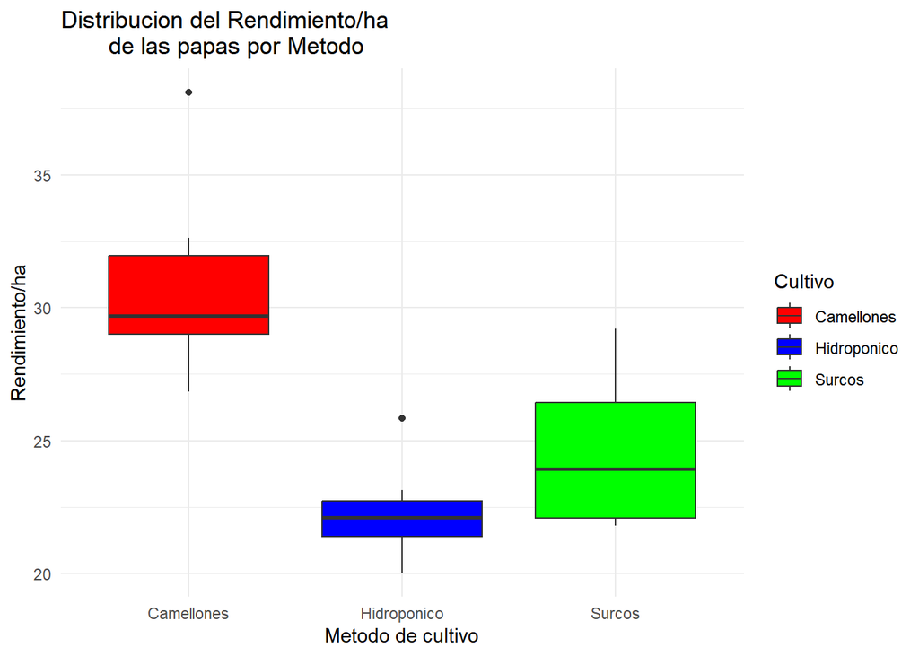

```
## Descriptive Statistics
## Rendimiento_ha by Cultivo
## Data Frame: datos5
## N: 45
##
##                     Camellones   Hidroponico   Surcos
## ----------------- ------------ ------------- --------
##              Mean        30.47         22.21    24.48
##           Std.Dev         2.83          1.34     2.70
##               Min        26.85         20.03    21.80
##                Q1        28.96         21.17    22.08
##            Median        29.70         22.12    23.94
##                Q3        31.97         22.79    26.48
##               Max        38.10         25.83    29.20
##               MAD         3.29          0.99     3.09
##               IQR         2.94          1.33     4.36
##                CV         0.09          0.06     0.11
##          Skewness         1.04          0.89     0.43
##       SE.Skewness         0.58          0.58     0.58
##          Kurtosis         0.95          1.22    -1.49
##           N.Valid        15.00         15.00    15.00
##                 N        15.00         15.00    15.00
##         Pct.Valid       100.00        100.00   100.00
```

### En cuanto al rendimiento por hectárea, el método por camellones mostró el mayor rendimiento promedio (30.47 kg/ha), seguido por el método por surcos (24.48 kg/ha) y el método hidropónico (22.21 kg/ha). El método camellones, aunque con el mayor rendimiento, presentó una mayor variabilidad (desviación estándar = 2.83 kg/ha), mientras que el hidropónico destacó por ser el más consistente (CV = 0.06), pero con un rendimiento inferior. El método por surcos presentó valores intermedios tanto en rendimiento como en dispersión.

## **Identificacion de valores atipicos multivariados**

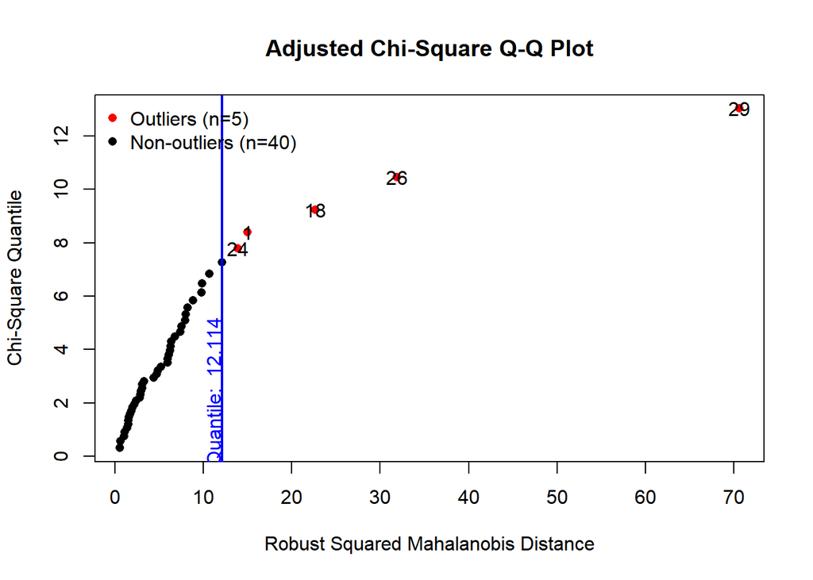

### Aunque se detectaron 5 atípicos multivariantes, no se eliminaron del análisis ya que representan datos reales del experimento, no son errores de medición, y aportan información valiosa sobre la variabilidad de los tratamientos. Además, el tamaño muestral es reducido y excluirlos podría afectar la validez y potencia del análisis.

## **Supuesto de normalidad**

### H0: Los datos siguen una distribucion normal multivariada

### H1: Los datos no siguen una distribucion normal multivariada

### alpha = 0.05

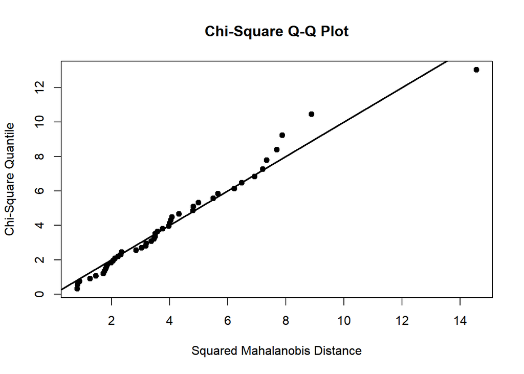

```
##              Test          Statistic            p value Result
## 1 Mardia Skewness   32.0389199977168 0.0428853639888225     NO
## 2 Mardia Kurtosis -0.577155553582798  0.563834378931052    YES
## 3             MVN               <NA>               <NA>     NO
```

### Con un nivel de significancia del 5%, se tiene suficiente evidencia para rechazar la hipótesis nula, concluyendo que los datos no siguen una distribución normal multivariada.

## **Supuesto de homogeneidad de matrices variancia covariancia**

### H0: Las matrices de covarianza son iguales

### H1: Al menos una matriz de covarianza es diferente

```
##
##  Box's M-test for Homogeneity of Covariance Matrices
##
## data:  datos5[-1]
## Chi-Sq (approx.) = 30.023, df = 20, p-value = 0.06948
```

### Con un nivel de significancia del 5%, el p-valor obtenido (0.06948) es mayor que 0.05. Por lo tanto, no se rechaza la hipótesis nula, concluyéndose que las matrices de covarianza son homogéneas entre los grupos.

## **Supuesto de correlación entre variables**

### H0: La matriz de correlaciones es igual a la matriz identidad

### H1: La matriz de correlaciones es diferente a la identidad

```
##        Bartlett's Sphericity Test
##
## Chi-Squared Value = 48.32312 , df = 6  and p-value: 1.02e-08
##
##        Correlation Matrix
##
##                     Peso  Diametro Materia_Seca Rendimiento_ha
## Peso           1.0000000 0.4206404    0.4198041      0.5051021
## Diametro       0.4206404 1.0000000    0.4250034      0.6035381
## Materia_Seca   0.4198041 0.4250034    1.0000000      0.5194947
## Rendimiento_ha 0.5051021 0.6035381    0.5194947      1.0000000
```

### Con un nivel de significancia del 5%, se rechaza la H0, concluyendo que las variables dependientes están significativamente correlacionadas

## **MANOVA**

### H0: No hay diferencias significativas entre los grupos de cultivo en las variables dependientes.

### H1: Existen diferencias significativas entre los grupos de cultivo en las variables dependientes.

```
##           Df  Pillai approx F num Df den Df    Pr(>F)
## Cultivo    2 0.94964   9.0411      8     80 9.307e-09 ***
## Residuals 42
## ---
## Signif. codes:  0 '***' 0.001 '**' 0.01 '*' 0.05 '.' 0.1 ' ' 1
```

### Con un nivel de significancia del 5%, rechazamos la hipótesis nula, lo que indica que hay diferencias significativas entre los cultivos en cuanto a las variables Peso, Diámetro, Materia Seca y Rendimiento por hectárea.

### Dado que el MANOVA indicó diferencias significativas entre los grupos de cultivo, se realiza una comparación por pares para identificar específicamente cuáles de los cultivos difieren entre sí

## **Comparacion por pares**

### H0 : No hay diferencia significativa entre los dos vectores o grupos.

### H1 : Hay una diferencia significativa entre los dos vectores o grupos.

```
## [1] "Trat:  Surcos y Camellones"
##           Df  Pillai approx F num Df den Df    Pr(>F)
## Cultivo    1 0.71593   15.752      4     25 1.464e-06 ***
## Residuals 28
## ---
## Signif. codes:  0 '***' 0.001 '**' 0.01 '*' 0.05 '.' 0.1 ' ' 1
##
## [1] "Trat:  Surcos y Hidroponico"
##           Df  Pillai approx F num Df den Df    Pr(>F)
## Cultivo    1 0.68572   13.637      4     25 4.983e-06 ***
## Residuals 28
## ---
## Signif. codes:  0 '***' 0.001 '**' 0.01 '*' 0.05 '.' 0.1 ' ' 1
##
## [1] "Trat:  Camellones y Hidroponico"
##           Df  Pillai approx F num Df den Df    Pr(>F)
## Cultivo    1 0.92009   71.965      4     25 2.395e-13 ***
## Residuals 28
## ---
## Signif. codes:  0 '***' 0.001 '**' 0.01 '*' 0.05 '.' 0.1 ' ' 1
```

### Después de hacer la comparación por pares de los tipos de cultivo, se observó que estos son significativamente diferentes entre sí:

### Surco vs Camellones: El valor de Pillai es de 0.716, lo que indica que el 71.6% de la variabilidad es explicada por el tipo de cultivo

### Surco vs Hidropónico: El valor de Pillai es de 0.686, lo que significa que el 68.6% de la variabilidad se debe al tipo de cultivo

### Camellones vs Hidropónico: El valor de Pillai es de 0.920, lo que implica que el 92% de la variabilidad es atribuible al tipo de cultivo

# **Pregunta 6**

### Se evaluaron cuatro variedades de tomate en un Diseño de Bloques Completos al Azar (DBCA) con cinco evaluadores. A cada variedad se le midieron cuatro características: altura de planta, rendimiento del fruto, contenido de azúcar y nivel de acidez. El objetivo es usar un MANOVA para saber si existen diferencias significativas entre las variedades considerando todas las variables juntas.

```
## # A tibble: 20 × 6
##    Variedad AlturaPlanta RendimientoFruto ContenidoAzucar NivelAcidez Evaluador
##    <fct>           <dbl>            <dbl>           <dbl>       <dbl> <fct>
##  1 1                84.2              510             4.5         4.1 1
##  2 1                79.6              498             4.3         4   2
##  3 1                82.1              523             4.6         4.2 3
##  4 1                85.3              507             4.4         4.1 4
##  5 1                80.9              495             4.5         4   5
##  6 2                92.4              610             5.1         3.9 1
##  7 2                89.7              598             5           4   2
##  8 2                94.1              615             5.3         3.8 3
##  9 2                91.5              602             5.2         3.9 4
## 10 2                88.3              590             5.1         4   5
## 11 3                76.5              430             3.8         4.3 1
## 12 3                78.9              445             3.9         4.4 2
## 13 3                74.2              420             3.7         4.5 3
## 14 3                77.6              435             3.8         4.4 4
## 15 3                75.1              440             3.9         4.3 5
## 16 4                86.8              560             4.9         4   1
## 17 4                88                572             5           3.9 2
## 18 4                84.6              555             4.8         4   3
## 19 4                87.2              563             4.9         4.1 4
## 20 4                85.7              550             5           4   5
```

## **Supuesto de normalidad multivariada**

### H0: Si hay normalidad multivariada

### H1: No hay normalidad multivariada

### alpha = 0.05

```
##
##  Shapiro-Wilk normality test
##
## data:  Z
## W = 0.55218, p-value = 0.000131
```

```
##
##  Shapiro-Wilk normality test
##
## data:  Z
## W = 0.55218, p-value = 0.000131
```

```
##
##  Shapiro-Wilk normality test
##
## data:  Z
## W = 0.55218, p-value = 0.000131
```

```
##
##  Shapiro-Wilk normality test
##
## data:  Z
## W = 0.55218, p-value = 0.000131
```

### Con un nivel de significancia del 5%, hay evidencia suficiente para rechazar la hipótesis nula de que los datos provienen de una distribución normal, ya que el p-valor es 0.000131, que es mucho menor que 0.05. Esto sugiere que los datos no siguen una distribución normal multivariada.

## **Supuesto de homogeneidad de matrices variancia covariancia**

### H0: Las matrices de varianza-covarianza son homogéneas

### H1: Las matrices de varianza-covarianza no son homogéneas

```
##
##  Box's M-test for Homogeneity of Covariance Matrices
##
## data:  datos6[, 2:5]
## Chi-Sq (approx.) = 54.418, df = 30, p-value = 0.004128
```

```
## Summary for Box's M-test of Equality of Covariance Matrices
##
## Chi-Sq:   54.41837
## df:   30
## p-value: 0.004128
##
## log of Covariance determinants:
##          1          2          3          4
##  -8.307122 -17.751250  -9.773282  -8.889616
##
## Eigenvalues:
##              1            2            3            4       pooled
## 1 1.233317e+02 1.020193e+02 9.432040e+01 7.078154e+01 97.369274958
## 2 4.437942e+00 1.490688e-01 1.741724e+00 4.914700e-01  1.942060445
## 3 7.343097e-03 1.590568e-03 4.803857e-03 6.368413e-03  0.007517177
## 4 6.139419e-05 8.074369e-07 7.216764e-05 6.220716e-04  0.004647420
##
## Statistics based on eigenvalues:
##                      1            2            3            4       pooled
## product   2.467531e-04 1.953125e-08 5.695313e-05 1.378125e-04  0.006606195
## sum       1.277770e+02 1.021700e+02 9.606700e+01 7.128000e+01 99.323500000
## precision 6.088427e-05 8.070229e-07 7.109657e-05 5.660573e-04  0.002867573
## max       1.233317e+02 1.020193e+02 9.432040e+01 7.078154e+01 97.369274958
```

### Con un p-valor de 0.004128, que es menor que el nivel de significancia común de 0.05, rechazamos la hipótesis nula de que las matrices de varianza-covarianza son homogéneas entre los grupos.

## **Supuesto de correlación entre variables**

### H0: La matriz de correlaciones es igual a la matriz identidad

### H1: La matriz de correlaciones es diferente a la identidad

```
##        Bartlett's Sphericity Test
##
## Chi-Squared Value = 137.53 , df = 6  and p-value: <2e-16
##
##        Correlation Matrix
##
##                  AlturaPlanta RendimientoFruto ContenidoAzucar NivelAcidez
## AlturaPlanta        1.0000000        0.9686902       0.9495263  -0.8662639
## RendimientoFruto    0.9686902        1.0000000       0.9860551  -0.8960523
## ContenidoAzucar     0.9495263        0.9860551       1.0000000  -0.9113530
## NivelAcidez        -0.8662639       -0.8960523      -0.9113530   1.0000000
```

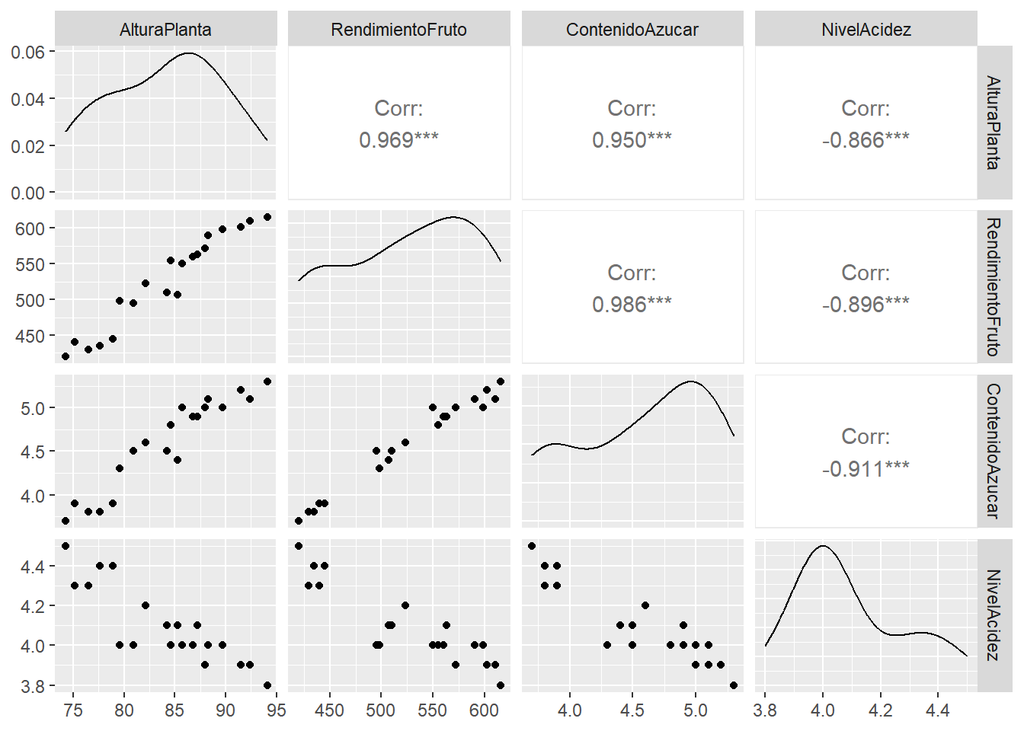

### Dado que el p-valor es muy bajo, podemos concluir que las variables AlturaPlanta, RendimientoFruto, ContenidoAzucar y NivelAcidez están significativamente correlacionadas. Esto sugiere que un análisis multivariado es adecuado para estudiar las relaciones entre estas características del cultivo y la calidad de los frutos.

## **Manova**

### H0: Los vectores de medias poblacionales son iguales entre las diferentes variedades.

### H1₁: Al menos un vector de medias poblacionales difiere entre las variedades.

### H0: No existen diferencias significativas entre los evaluadores.

### H1: Sí existen diferencias significativas entre los evaluadores, lo cual justificaría el uso del bloque.

```
##           Df Pillai approx F num Df den Df    Pr(>F)
## Variedad   3 1.8493   4.4198     12     33 0.0003377 ***
## Evaluador  4 1.1460   1.2046     16     48 0.2990440
## Residuals 12
## ---
## Signif. codes:  0 '***' 0.001 '**' 0.01 '*' 0.05 '.' 0.1 ' ' 1
```

### Para variedad:

### Con un nivel de significancia del 5%, el valor p (0.0003) es menor que 0.05.Por lo tanto, se rechaza H0 y se concluye que existen diferencias significativas entre las variedades respecto a las variables multivariadas (AlturaPlanta, RendimientoFruto, ContenidoAzucar y NivelAcidez).

### Con un nivel de significancia del 5%, el valor p (0.2990) es mayor que 0.05. Por lo tanto, no se rechaza H0, lo que indica que no hay evidencia suficiente para afirmar que los evaluadores influyen significativamente en las variables medidas.

## **Anova para cada variable dependiente**

```
##  Response AlturaPlanta :
##             Df Sum Sq Mean Sq F value    Pr(>F)
## Variedad     3 585.83 195.278 54.2765 2.975e-07 ***
## Evaluador    4  20.54   5.134  1.4271    0.2841
## Residuals   12  43.17   3.598
## ---
## Signif. codes:  0 '***' 0.001 '**' 0.01 '*' 0.05 '.' 0.1 ' ' 1
##
##  Response RendimientoFruto :
##             Df Sum Sq Mean Sq  F value    Pr(>F)
## Variedad     3  79627 26542.2 252.1026 4.229e-11 ***
## Evaluador    4    262    65.4   0.6217    0.6558
## Residuals   12   1263   105.3
## ---
## Signif. codes:  0 '***' 0.001 '**' 0.01 '*' 0.05 '.' 0.1 ' ' 1
##
##  Response ContenidoAzucar :
##             Df Sum Sq Mean Sq  F value    Pr(>F)
## Variedad     3 5.1055 1.70183 138.9252 1.392e-09 ***
## Evaluador    4 0.0130 0.00325   0.2653    0.8946
## Residuals   12 0.1470 0.01225
## ---
## Signif. codes:  0 '***' 0.001 '**' 0.01 '*' 0.05 '.' 0.1 ' ' 1
##
##  Response NivelAcidez :
##             Df Sum Sq  Mean Sq F value    Pr(>F)
## Variedad     3 0.6055 0.201833 26.3261 1.454e-05 ***
## Evaluador    4 0.0120 0.003000  0.3913     0.811
## Residuals   12 0.0920 0.007667
## ---
## Signif. codes:  0 '***' 0.001 '**' 0.01 '*' 0.05 '.' 0.1 ' ' 1
```

### Los resultados muestran que la Variedad es significativamente diferente en todas las variables dependientes, mientras que Evaluador no presenta diferencias significativas en ninguna de las variables.

## Pruebas de Comparación por Pares (Tukey)

## **Altura planta**

### H0: No hay diferencia significativa en la altura de las plantas entre las variedades.

### H1: Hay diferencia significativa en la altura de las plantas entre al menos dos de las variedades.

### alpha = 0.05

```
##   Tukey multiple comparisons of means
##     95% family-wise confidence level
##
## Fit: aov(formula = AlturaPlanta ~ Variedad, data = datos6)
##
## $Variedad
##       diff         lwr        upr     p adj
## 2-1   8.78   5.1692162  12.390784 0.0000176
## 3-1  -5.96  -9.5707838  -2.349216 0.0011858
## 4-1   4.04   0.4292162   7.650784 0.0257325
## 3-2 -14.74 -18.3507838 -11.129216 0.0000000
## 4-2  -4.74  -8.3507838  -1.129216 0.0084223
## 4-3  10.00   6.3892162  13.610784 0.0000034
```

### Variedad 2 vs. Variedad 1: Significativa, la Variedad 2 es más alta.

### Variedad 3 vs. Variedad 1: Significativa, la Variedad 3 es más baja.

### Variedad 4 vs. Variedad 1: Significativa, la Variedad 4 es más alta.

### Variedad 3 vs. Variedad 2: Altamente significativa, la Variedad 3 es más baja.

### Variedad 4 vs. Variedad 2: Significativa, la Variedad 4 es más baja.

### Variedad 4 vs. Variedad 3: Altamente significativa, la Variedad 4 es más alta.

## **RendimientoFruto**

### H0: No hay diferencia significativa en el rendimiento de los frutos entre las variedades.

### H1: Hay diferencia significativa en el rendimiento de los frutos entre al menos dos de las variedades.

### alpha = 0.05

```
##   Tukey multiple comparisons of means
##     95% family-wise confidence level
##
## Fit: aov(formula = RendimientoFruto ~ Variedad, data = datos6)
##
## $Variedad
##       diff        lwr        upr    p adj
## 2-1   96.4   78.73335  114.06665 0.00e+00
## 3-1  -72.6  -90.26665  -54.93335 0.00e+00
## 4-1   53.4   35.73335   71.06665 1.10e-06
## 3-2 -169.0 -186.66665 -151.33335 0.00e+00
## 4-2  -43.0  -60.66665  -25.33335 1.73e-05
## 4-3  126.0  108.33335  143.66665 0.00e+00
```

### Variedad 2 vs. Variedad 1: Altamente significativa, la Variedad 2 tiene un mayor rendimiento.

### Variedad 3 vs. Variedad 1: Altamente significativa, la Variedad 3 tiene un menor rendimiento.

### Variedad 4 vs. Variedad 1: Altamente significativa, la Variedad 4 tiene un mayor rendimiento.

### Variedad 3 vs. Variedad 2: Altamente significativa, la Variedad 3 tiene un menor rendimiento.

### Variedad 4 vs. Variedad 2: Altamente significativa, la Variedad 4 tiene un menor rendimiento.

### Variedad 4 vs. Variedad 3: Altamente significativa, la Variedad 4 tiene un mayor rendimiento.

## **Contenido de Azucar**

### H0: No hay diferencia significativa en el contenido de azúcar entre las variedades.

### H1: Hay diferencia significativa en el contenido de azúcar entre al menos dos de las variedades.

### alpha = 0.05

```
##   Tukey multiple comparisons of means
##     95% family-wise confidence level
##
## Fit: aov(formula = ContenidoAzucar ~ Variedad, data = datos6)
##
## $Variedad
##      diff        lwr         upr     p adj
## 2-1  0.68  0.4990532  0.86094678 0.0000001
## 3-1 -0.64 -0.8209468 -0.45905322 0.0000001
## 4-1  0.46  0.2790532  0.64094678 0.0000102
## 3-2 -1.32 -1.5009468 -1.13905322 0.0000000
## 4-2 -0.22 -0.4009468 -0.03905322 0.0147691
## 4-3  1.10  0.9190532  1.28094678 0.0000000
```

### Variedad 2 vs. Variedad 1: Altamente significativa, la Variedad 2 tiene más contenido de azúcar.

### Variedad 3 vs. Variedad 1: Altamente significativa, la Variedad 3 tiene menos contenido de azúcar.

### Variedad 4 vs. Variedad 1: Altamente significativa, la Variedad 4 tiene más contenido de azúcar.

### Variedad 3 vs. Variedad 2: Altamente significativa, la Variedad 3 tiene menos contenido de azúcar.

### Variedad 4 vs. Variedad 2: Significativa, la Variedad 4 tiene menos contenido de azúcar.

### Variedad 4 vs. Variedad 3: Altamente significativa, la Variedad 4 tiene más contenido de azúcar.

## **Nivel de acidez**

### H0: No hay diferencia significativa en el nivel de acidez entre las variedades

### H1: Hay diferencia significativa en el nivel de acidez entre al menos dos de las variedades.

### alpha = 0.05

```
##   Tukey multiple comparisons of means
##     95% family-wise confidence level
##
## Fit: aov(formula = NivelAcidez ~ Variedad, data = datos6)
##
## $Variedad
##      diff         lwr         upr     p adj
## 2-1 -0.16 -0.30588396 -0.01411604 0.0291638
## 3-1  0.30  0.15411604  0.44588396 0.0001233
## 4-1 -0.08 -0.22588396  0.06588396 0.4226637
## 3-2  0.46  0.31411604  0.60588396 0.0000006
## 4-2  0.08 -0.06588396  0.22588396 0.4226637
## 4-3 -0.38 -0.52588396 -0.23411604 0.0000075
```

### Variedad 2 vs. Variedad 1: Significativa, la Variedad 2 tiene menor acidez.

### Variedad 3 vs. Variedad 1: Altamente significativa, la Variedad 3 tiene mayor acidez.

### Variedad 4 vs. Variedad 1: No significativa.

### Variedad 3 vs. Variedad 2: Altamente significativa, la Variedad 3 tiene mayor acidez.

### Variedad 4 vs. Variedad 2: No significativa.

### Variedad 4 vs. Variedad 3: Altamente significativa, la Variedad 4 tiene menor acidez.

## **Pregunta 7**

### En este experimento se investiga el efecto de dos factores (luz y riego) sobre el crecimiento de plantas en un invernadero.Se miden la altura de la planta y el número de hojas después de un mes de crecimiento bajo diferentes condiciones de luz y riego.

### **Las variables dependientes que se medirán son:**

### Altura de la planta (Alt) en cm.

### Número de hojas (Hojas).

### **Los factores a estudiar son:**

### Luz: 2 niveles (Baja intensidad y Alta intensidad).

### Riego: 2 niveles (Riego bajo y Riego alto).

```r
library(readxl)
library(DT)
library(tidyverse)
library(mvnormtest)
library(psych)
library(heplots)
library(MVN)
library(dplyr)
```

|  | LUZ | RIEGO | ALTURA | HOJAS |
| --- | --- | --- | --- | --- |
| 1 | Baja intensidad | Bajo | 15.2 | 10 |
| 2 | Baja intensidad | Bajo | 14.7 | 9 |
| 3 | Baja intensidad | Bajo | 13.9 | 8 |
| 4 | Baja intensidad | Bajo | 16 | 11 |
| 5 | Baja intensidad | Bajo | 14.4 | 9 |
| 6 | Baja intensidad | Alto | 18.3 | 14 |
| 7 | Baja intensidad | Alto | 17.9 | 13 |
| 8 | Baja intensidad | Alto | 19.2 | 15 |
| 9 | Baja intensidad | Alto | 18.7 | 14 |
| 10 | Baja intensidad | Alto | 19 | 13 |

[output cut: 10 more lines]

## **Análisis exploratorio**

|  | LUZ | RIEGO | Media_Altura | Mediana_Altura | Desviacion_Altura | Q1_Altura | Q3_Altura | Min_Altura | Max_Altura |
| --- | --- | --- | --- | --- | --- | --- | --- | --- | --- |
| 1 | Alta intensidad | Alto | 27.12 | 27 | 0.6260990336999418 | 26.7 | 27.3 | 26.5 | 28.1 |
| 2 | Alta intensidad | Bajo | 21.68 | 21.8 | 0.5357238094391558 | 21.4 | 22.1 | 20.9 | 22.2 |
| 3 | Baja intensidad | Alto | 18.62 | 18.7 | 0.5263078946776308 | 18.3 | 19 | 17.9 | 19.2 |
| 4 | Baja intensidad | Bajo | 14.84 | 14.7 | 0.801872807869178 | 14.4 | 15.2 | 13.9 | 16 |

### * Alta intensidad de luz y Alto riego conducen a las plantas más altas, mientras que las combinaciones con Baja intensidad y Bajo riego resultan en alturas más bajas.

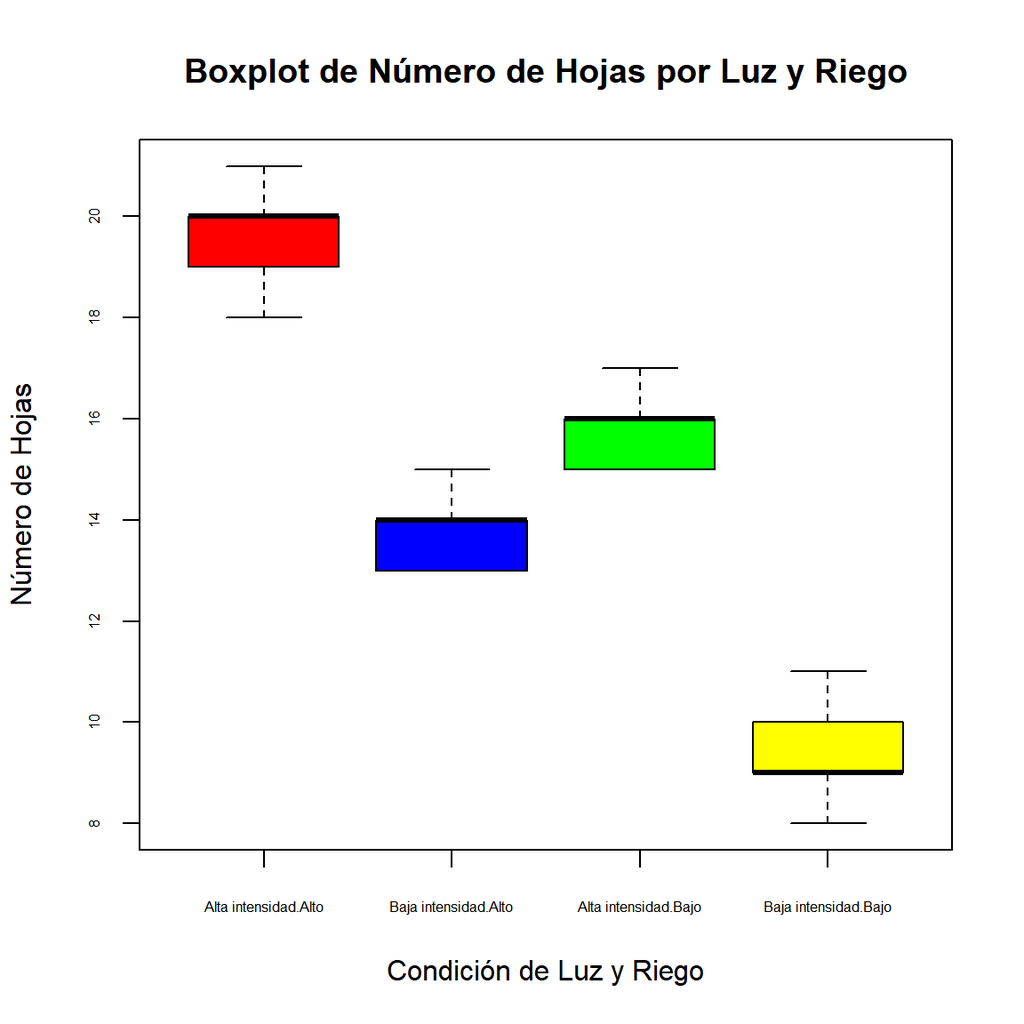

|  | RIEGO | Media_Hojas | Mediana_Hojas | Desviacion_Hojas | Q1_Hojas | Q3_Hojas | Min_Hojas | Max_Hojas |
| --- | --- | --- | --- | --- | --- | --- | --- | --- |
| 1 | Alto | 16.7 | 16.5 | 3.19895816373602 | 14 | 19.75 | 13 | 21 |
| 2 | Bajo | 12.6 | 13 | 3.502380143083653 | 9.25 | 15.75 | 8 | 17 |

### * Las plantas con Alta intensidad de luz tienen en promedio más hojas que las plantas con Baja intensidad, especialmente cuando se combina con Alto riego.

### * Bajo riego tiende a limitar el número de hojas en comparación con las plantas que reciben Alto riego, lo que refleja que el riego tiene un efecto positivo en el crecimiento de las hojas.

## **Valores atipicos multivariantes**

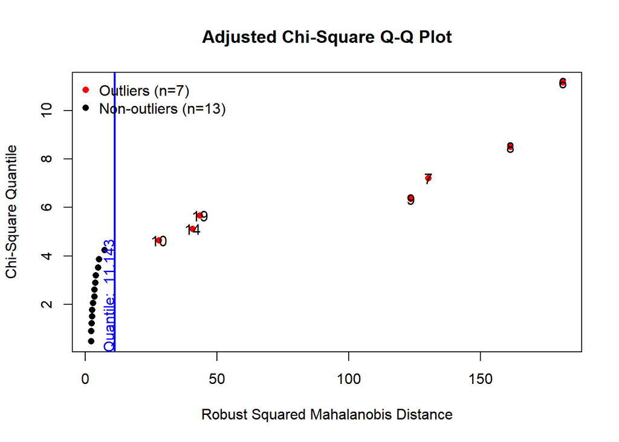

### Existen 7 valores atipicos multivariantes, sin embargo no se eliminaran debido a que consideramos que al hacerlo estaremos afectando el analisis por la poca cantidad de datos que tiene nuestro experimento factorial

## **Supuesto de normalidad multivariada**

### Hipótesis nula (H₀): Los datos siguen una distribución normal multivariada.

### Hipótesis alternativa (H₁): Los datos no siguen una distribución normal multivariada.

```r
datosc = datos7
datosc
trat1 = datosc %>% filter(LUZ == "Baja intensidad", RIEGO == "Bajo") %>%
  dplyr::select(ALTURA, HOJAS)
trat2 = datosc %>% filter(LUZ == "Baja intensidad", RIEGO == "Alto") %>%
  dplyr::select(ALTURA, HOJAS)
trat3 = datosc %>% filter(LUZ == "Alta intensidad", RIEGO == "Bajo") %>%
  dplyr::select(ALTURA, HOJAS)
trat4 = datosc %>% filter(LUZ == "Alta intensidad", RIEGO == "Alto") %>%
  dplyr::select(ALTURA, HOJAS)
```

```
##
##  Shapiro-Wilk normality test
##
## data:  Z
## W = 0.96358, p-value = 0.8327
```

```
##
##  Shapiro-Wilk normality test
##
## data:  Z
## W = 0.80229, p-value = 0.08459
```

```
##
##  Shapiro-Wilk normality test
##
## data:  Z
## W = 0.79066, p-value = 0.06786
```

```
##
##  Shapiro-Wilk normality test
##
## data:  Z
## W = 0.77827, p-value = 0.05326
```

### Dado que los p-valores en todos los casos son mayores que 0.05, no rechazamos la hipótesis nula (H₀), lo que indica que no hay evidencia suficiente para afirmar que los datos se desvían de una distribución normal multivariada. En otras palabras, los datos son compatibles con la hipótesis de normalidad multivariada y, por lo tanto, podemos asumir que las variables siguen una distribución normal conjunta.

## **Supuesto de homogeneidad de matrices variancia covariancia**

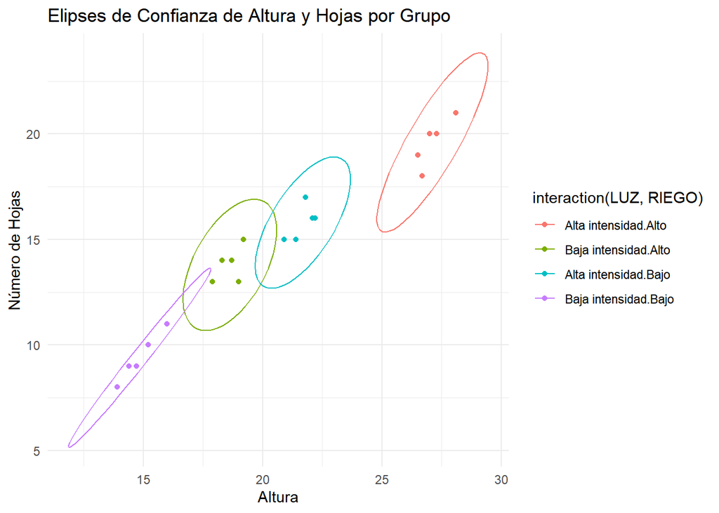

### El gráfico de elipses de confianza muestra la distribución de los datos para los diferentes grupos, y las elipses representando las áreas donde caen el 95% de las observaciones de cada grupo nos indican si las matrices de covarianza son homogéneas. Aunque las elipses para ciertos grupos presentan algunas diferencias en tamaño y forma, la superposición parcial entre ellas sugiere que existe una similitud en las distribuciones de los datos, lo que indica que probablemente sí hay homogeneidad en las matrices de covarianza.

### Hipótesis nula (H₀): Las matrices de covarianza son iguales entre los grupos.

### Hipótesis alternativa (H₁): Las matrices de covarianza no son iguales.

```
##
##  Box's M-test for Homogeneity of Covariance Matrices
##
## data:  Y
## Chi-Sq (approx.) = 7.1956, df = 9, p-value = 0.6168
```

### Dado que el p-valor = 0.6168 es mayor que 0.05, no rechazamos la hipótesis nula (H₀). Esto implica que no hay evidencia suficiente para afirmar que las matrices de covarianza son diferentes entre los grupos. En otras palabras, los datos cumplen con el supuesto de homogeneidad de matrices de covarianza, lo que significa que las matrices de covarianza para los distintos grupos son similares.

### **Supuesto de variables dependientes correlacionadas**

### H₀: Las variables no están correlacionadas (la matriz de correlaciones es la identidad).

### H₁: Sí hay correlación entre las variables (la matriz no es identidad).

```
## $chisq
## [1] 54.93375
##
## $p.value
## [1] 1.246616e-13
##
## $df
## [1] 1
```

### Como el p-valor < 0.05, rechazamos H₀. Un valor p bajo nos muestra que la probabilidad de que la matriz de correlación sea la identidad (sin correlación) es extremadamente baja. Esto confirma que las variables están correlacionadas y que la matriz de correlación observada es significativamente diferente de la matriz identidad

### Durante este analisis se comprobo los suspuestos que debe tener nuestro experimento antes de realizar un manova, esto se pudo comprobar en cada sección, debido a lo anterior ahora se procede a hacer el manova y se descompone la matriz para hallar la suma de cuadrdaos de cada factor y su interaccion(FLUZ,FRIEGO,FLUZRIEGO), la suma de cuadrados del error(W) y la suma de cuadrados total(T), además hallaremos la variabilidad explicada por el modelo(eta2)

## **Determinacion de la matriz residual y las matrices factoriales**

```r
modelo = manova(cbind(ALTURA, HOJAS) ~ LUZ *RIEGO, data = datos7)
Matrices = summary(modelo)$SS
FLUZ = Matrices$LUZ
FRIEGO = Matrices$RIEGO
FLUZRIEGO = Matrices$`LUZ:RIEGO`
W = Matrices$Residuals
T = FLUZ + FRIEGO+ FLUZRIEGO + W
eta2 = 1 - det(W)/det(T)
```

```r
FLUZ
```

```
##          ALTURA   HOJAS
## ALTURA 294.1445 233.935
## HOJAS  233.9350 186.050
```

### El efecto de la luz en las plantas tiene una suma de cuadrados de 294.1445 para Altura y 186.050 para Número de Hojas. Esto indica que Luz tiene un efecto significativo sobre las plantas, ya que está explicando una gran proporción de la variabilidad

```r
FRIEGO
```

```
##          ALTURA  HOJAS
## ALTURA 106.2605 94.505
## HOJAS   94.5050 84.050
```

### El riego tiene una suma de cuadrados de 106.2605 para Altura y 84.050 para Número de Hojas, lo que indica que el riego también tiene un efecto significativo, pero menor que el de la luz.

```r
FLUZRIEGO
```

```
##         ALTURA  HOJAS
## ALTURA  3.4445 -1.245
## HOJAS  -1.2450  0.450
```

### La interacción entre Luz y Riego tiene una suma de cuadrados de 3.4445 para Altura y 0.450 para Número de Hojas, lo que sugiere que aunque hay una interacción entre Luz y Riego, el efecto no es tan fuerte como los efectos individuales de estos factores.

```r
W
```

```
##        ALTURA HOJAS
## ALTURA  6.396  8.16
## HOJAS   8.160 16.00
```

### El error (residuos) tiene una suma de cuadrados de 6.396 para Altura y 16.00 para Número de Hojas, lo que indica que la variabilidad no explicada por el modelo es relativamente baja.

```r
T
```

```
##          ALTURA   HOJAS
## ALTURA 410.2455 335.355
## HOJAS  335.3550 286.550
```

### La variabilidad total para Altura es de 410.2455 y para Número de Hojas es de 286.550, lo que indica la magnitud de la variabilidad presente en los datos.

```r
eta2
```

```
## [1] 0.9929803
```

### El 99.3% de la variabilidad conjunta en ALTURA y HOJAS es explicada por LUZ, RIEGO y su interacción.

```
##           Df  Pillai approx F num Df den Df    Pr(>F)
## LUZ        1 0.98309   436.04      2     15 5.140e-14 ***
## RIEGO      1 0.95111   145.89      2     15 1.477e-10 ***
## LUZ:RIEGO  1 0.68656    16.43      2     15 0.0001664 ***
## Residuals 16
## ---
## Signif. codes:  0 '***' 0.001 '**' 0.01 '*' 0.05 '.' 0.1 ' ' 1
```

### * LUZ y RIEGO por separado afectan el crecimiento de las plantas (ALTURA y HOJAS), y su interacción también tiene un efecto significativo. Esto significa que la relación entre estos dos factores debe considerarse cuidadosamente, ya que su combinación influye de manera significativa en el crecimiento de las plantas.